# Final Report

Nathan Butler

2025-05-15

```r
# Load Required Libraries
library(Lahman)
library(tidyverse)
library(readr)
```

Presentation can be found here

# Background

The St. Louis Cardinals have historically been a team that is at the top of the standings. They are always competitive and have a large list of Hall of Famers that have played for them. Cardinals have the second most World Series Wins (11) among all teams, except for the Yankees and have dominated in the division. For example here is a plot that shows all of their wins by the year.

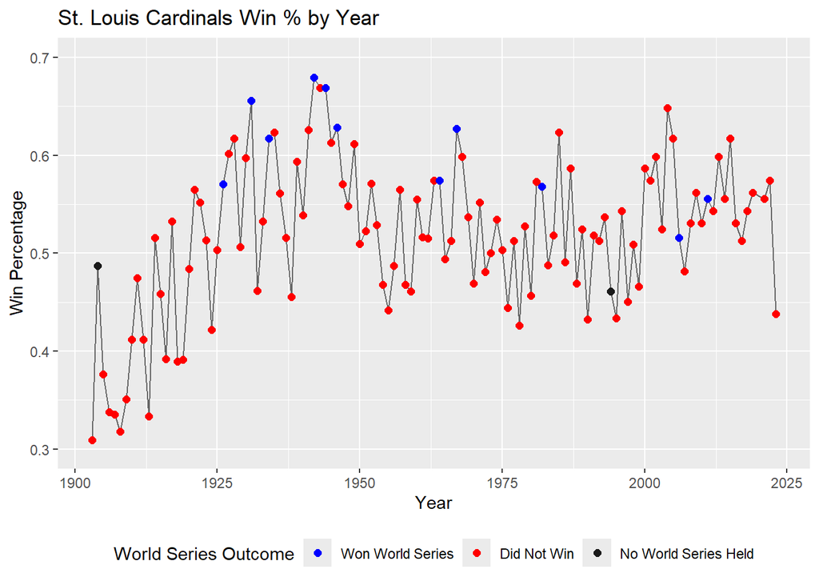

As you can see there is history in the Cardinals for being a good team and having lots of wins. Specifically if we look at the recent Cardinals (since 2000), and see how they fared in the division we will see that they have been successful.

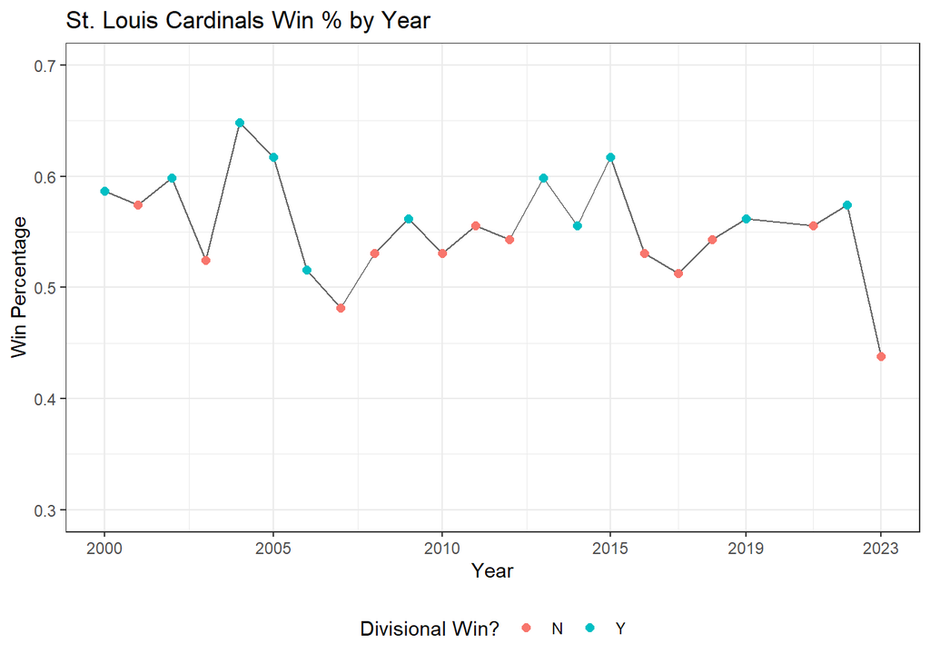

```r
ggplot(Cards %>% filter(yearID >= 2000), aes(x = yearID, y = Wpct)) +
  geom_line(color = "gray40") +
  geom_point(aes(color = DivWin), size = 2) +
  scale_y_continuous(limits = c(0.3, 0.7)) +
  scale_x_continuous(breaks = c(2000, 2005, 2010, 2015, 2019, 2023)) +
  labs(
    title = "St. Louis Cardinals Win % by Year",
    x = "Year",
    y = "Win Percentage",
    color = "Divisional Win?"
  ) +
  theme_bw() +
  theme(legend.position = "bottom")
```

As you can see the Cardinals have been very successful in their division in the past. In 2023 the Cardinals finished dead last in their division while winning it the previous year, and had one of the worst records in team history. The 2023 season was a change in the way the Cardinals played and viewed the team for the future for many fans. What some people thought might just be an off couple of months turned into one of the worst displays of baseball in Cardinals history that led them to their worst record in the 21st century and further from the playoffs than they thought.

In 2023 there was what seemed like an anomaly to people that are not Cardinals fans, but to Cardinals fans it was an exposure that could be seen coming for years.

# Research Question

The point of this paper is to look at factors that led to the Cardinals downfall of 2023. We will look specifically at the pitching downfall that led to a major difference production for the team. Looking at this plot below you will see the difference in the years and how pitching was a major difference in the season.

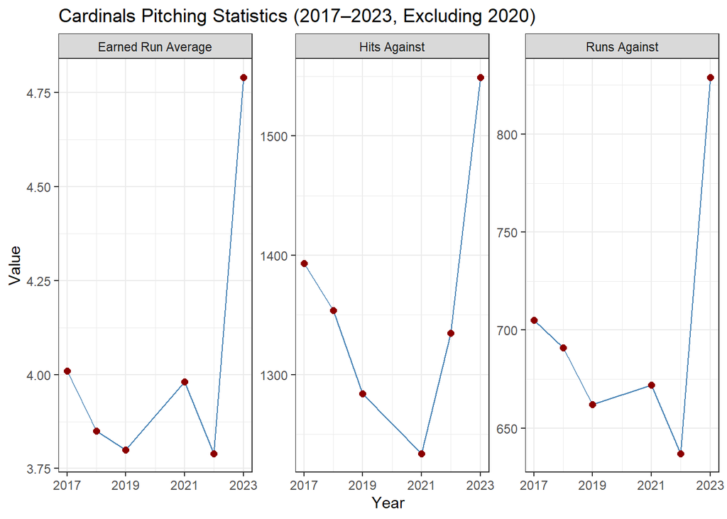

```r
cards_long <- Cards %>%
  filter(yearID >= 2017 & yearID != 2020) %>%
  select(yearID, HA, RA, ERA) %>%
  pivot_longer(cols = c(HA, RA, ERA), names_to = "Stat", values_to = "Value") %>%
  mutate(Stat = recode(Stat,
                       "HA" = "Hits Against",
                       "RA" = "Runs Against",
                       "ERA" = "Earned Run Average"))

# Plot
ggplot(cards_long, aes(x = yearID, y = Value)) +
  geom_line(group = 1, color = "steelblue") +
  geom_point(color = "darkred", size = 2) +
  facet_wrap(~ Stat, scales = "free_y") +
  scale_x_continuous(limits = c(2017, 2023), breaks = seq(2017, 2023, by = 2)) +
  labs(
    title = "Cardinals Pitching Statistics (2017–2023, Excluding 2020)",
    x = "Year",
    y = "Value"
  ) +
  theme_bw()
```

All of these categories really shot up during this year and it led to one of the worst records in Cardinals history. When looking at this tibble you can see how just how different the pitching performance was during this time.

```r
Cards %>%
  filter(yearID >= 2017 & yearID != 2020) %>%
  select("Year" = yearID, W, L, Rank, R, RA, ERA, HRA, SOA)
```

```
##   Year  W  L Rank   R  RA  ERA HRA  SOA
## 1 2017 83 79    3 761 705 4.01 183 1351
## 2 2018 88 74    3 759 691 3.85 144 1337
## 3 2019 91 71    1 764 662 3.80 191 1399
## 4 2021 90 72    2 706 672 3.98 152 1225
## 5 2022 93 69    1 772 637 3.79 146 1177
## 6 2023 71 91    5 719 829 4.79 179 1215
```

[figure not shown]

```r
library(mlbplotR)

lahman_to_mlbplotr <- tibble::tribble(
  ~teamID, ~team_abbr,
  "LAA", "LAA",
  "ARI", "AZ",
  "ATL", "ATL",
  "BAL", "BAL",
  "BOS", "BOS",
  "CHN", "CHC",
  "CHA", "CWS",
  "CIN", "CIN",
  "CLE", "CLE",
  "COL", "COL",
  "DET", "DET",
  "HOU", "HOU",
  "KCA", "KC",
  "LAN", "LAD",
  "MIA", "MIA",
  "MIL", "MIL",
  "MIN", "MIN",
  "NYA", "NYY",
  "NYN", "NYM",
  "OAK", "OAK",
  "PHI", "PHI",
  "PIT", "PIT",
  "SDN", "SD",
  "SEA", "SEA",
  "SFN", "SF",
  "SLN", "STL",
  "TBA", "TB",
  "TEX", "TEX",
  "TOR", "TOR",
  "WAS", "WSH"
)

# Get 2022 and 2023 teams data
teams_recent <- Lahman::Teams %>%
  filter(yearID %in% c(2022, 2023)) %>%
  left_join(lahman_to_mlbplotr, by = "teamID") %>%
  filter(!is.na(team_abbr)) %>%
  mutate(year = factor(yearID))

# Plot with facet_wrap by year
ggplot(teams_recent, aes(x = W, y = RA)) +
  geom_mlb_logos(aes(team_abbr = team_abbr), width = 0.08) +
  facet_wrap(~ year) +
  labs(
    title = "Runs Against vs Wins (2022 & 2023)",
    x = "Wins",
    y = "Runs Against"
  ) +
  theme_bw()
```

From this plot you can see that the Cardinals moved to a completely different region of the graph. Most of the teams that had low wins and high runs against stayed the same, while the Cardinals moved into a region unlike most of the other teams. If we now look into differences in Runs Against and ERA over the years you will see the similar pattern of the Cardinals moving into a territory of bad baseball.

[figure not shown]

[figure not shown]

Now as you can see almost every teams ERA increased from 2022-2023, but if you notice which teams had the largest increase are some of the worst teams in baseball for the 2023 season. The Cardinals were trending in a bad direction if they were grouped in a category with the Athletics, Angels, and White Sox.

# Cardinals Roster

Between 2022 and 2023 there were some major losses to the Cardinals. They lost Albert Pujols and Yadier Molina to retirement. These are both future Hall of Famers that were two of the best players to ever put on a Cardinal uniform and even baseball uniform in general. The rest of the roster stayed pretty similar except for a couple of additions. The team added some young rookies and signed Willson Contreras from the Cubs as Molina’s replacement. Less than 2 months into the season, the Cardinals announced they were benching Contreras for his bad play as a catcher. The front office blamed Contreras for the decline in pitching performance rather than blaming the pitchers for not being good. The starting rotation had 4 pitchers older than 31 years old and that included Wainwright who 40 and could not throw over 89 MPH. This also included Miles Mikolas who statistically has been one of the worst pitchers in the MLB since 2022 with leading the MLB in Hits Against while having a very low strikeout rate. He consistently has finished near the top of ERA ratings, but consistently gets a lot of starts while not producing like the ‘Ace’ he was paid to be.

This is why we will look into the Statcast data to find any information we can about the team and what really changed. I believe there will large differences in the way that the pitchers were pitching and how they were going about their game plans.

# Statcast Data

We will look into the 2021-2023 pitching data from Statcast. This will give us 2 years of baseline performance before a bad year where we can look into the differences. We will compare the differences between the Cardinals past years and the differences between better teams during those years to see how they compare.

## Load in the Data

```r
# Load in Statcast Data
stat2021 <- readRDS('statcast2021.RData')
stat2022 <- readRDS('statcast2022.RData')
stat2023 <- readRDS('statcast2023.RData')

PLAYERIDMAP <- read_csv("C:/Users/qbcar/github/Stat430Baseball/PLAYERIDMAP.csv")
```

```r
cards_2021 <- stat2021 %>%
  filter(home_team == 'STL' | away_team == 'STL') %>%
  left_join(PLAYERIDMAP %>% select(IDPLAYER, TEAM, MLBID, MLBNAME),
            by = c("pitcher_id" = 'MLBID'))

cards_2022 <- stat2022 %>%
  filter(home_team == 'STL' | away_team == 'STL') %>%
  left_join(PLAYERIDMAP %>% select(IDPLAYER, TEAM, MLBID, MLBNAME),
            by = c("pitcher_id" = 'MLBID'))

cards_2023 <- stat2023 %>%
  filter(home_team == 'STL' | away_team == 'STL') %>%
  left_join(PLAYERIDMAP %>% select(IDPLAYER, TEAM, MLBID, MLBNAME),
            by = c("pitcher_id" = 'MLBID'))

cards_pitch21 <- cards_2021 %>%
  filter((home_team == 'STL' & half_inning == 'top') |
           (away_team == 'STL' & half_inning == 'bottom'))
cards_pitch22 <- cards_2022 %>%
  filter((home_team == 'STL' & half_inning == 'top') |
           (away_team == 'STL' & half_inning == 'bottom'))
cards_pitch23 <- cards_2023 %>%
  filter((home_team == 'STL' & half_inning == 'top') |
           (away_team == 'STL' & half_inning == 'bottom'))
```

The following code creates a function that makes a strikezone.

```r
library(ggdensity)

# create geom to visualize the strikezone
geom_strikezone = function(sz_top = 3.8, sz_bot = 1.1) {
  plate_width = 17 + 2 * (9 / pi)
  sz_left = -(plate_width / 2) / 12
  sz_right = (plate_width / 2) / 12
  strikezone = data.frame(
    x = c(sz_left, sz_left, sz_right, sz_right, sz_left),
    y = c(sz_bot, sz_top, sz_top, sz_bot, sz_bot)
  )
  geom_path(
    mapping = aes(.data$x, .data$y),
    data = strikezone,
    linewidth = 0.5,
    linetype = 1,
    color = "black"
  )
}
location_func <- function(pitchers){
  location_plot = {
    ggplot(pitchers) +
      aes(x = plate_x, y = plate_z) +
      xlim(c(-4, 4)) +
      ylim(c(-2, 6)) +
      xlab("") +
      ylab("") +
      theme_bw() +
      coord_fixed() +
      facet_wrap(vars(pitch_name))
  }

  location_plot +
    geom_hdr(
      method = method_kde(h = 0.75),
      probs = c(0.90, 0.70, 0.50, 0.40, 0.30, 0.20),
      show.legend = FALSE,
      aes(fill = after_stat(probs)),
      alpha = 0.75
    )  +
    scale_fill_brewer(
      palette = "RdBu",
      direction = -1
    ) +
    geom_strikezone()
}
```

## Cardinals Pitchers

One of the first things we will look into is pitching usage. Looking into the players the were pitching for the Cardinals and see what is the difference in mindset of using certain pitches. So first we will look at the overall usage trends for each year by the pitch type.

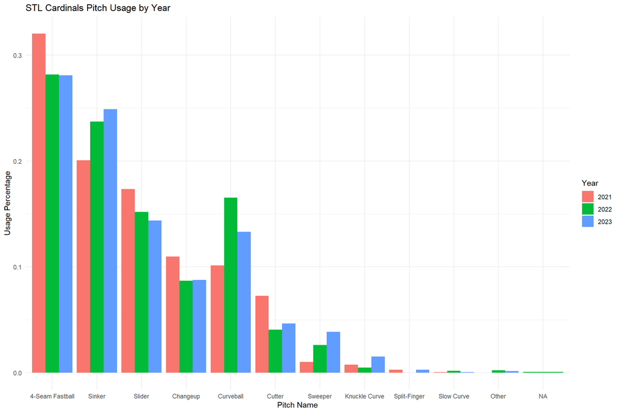

```r
cards_perc21 <- cards_pitch21 %>%
  group_by(pitch_name) %>%
  summarise(tot = n()) %>%
  mutate(usage = round(tot / sum(tot), digits = 4)) %>%
  arrange(desc(usage)) %>%
  mutate(year = 2021)

cards_perc22 <- cards_pitch22 %>%
  group_by(pitch_name) %>%
  summarise(tot = n()) %>%
  mutate(usage = round(tot / sum(tot), digits = 4)) %>%
  arrange(desc(usage)) %>%
  mutate(year = 2022)

cards_perc23 <- cards_pitch23 %>%
  group_by(pitch_name) %>%
  summarise(tot = n()) %>%
  mutate(usage = round(tot / sum(tot), digits = 4)) %>%
  arrange(desc(usage)) %>%
  mutate(year = 2023)

cards_all <- bind_rows(cards_perc21, cards_perc22, cards_perc23)

pitch_order <- cards_perc21 %>%
  arrange(desc(usage)) %>%
  pull(pitch_name)

cards_all$pitch_name <- factor(cards_all$pitch_name, levels = pitch_order)

# Step 3: Plot
ggplot(cards_all, aes(x = pitch_name, y = usage, fill = factor(year))) +
  geom_bar(stat = "identity", position = "dodge") +
  labs(
    title = "STL Cardinals Pitch Usage by Year",
    x = "Pitch Name",
    y = "Usage Percentage",
    fill = "Year"
  ) +
  theme_minimal()
```

As you can see there was a decrease in the usage of 4-Seam, Slider, and Changeup while there was an increase in the usage of Sinker and Curveball. This seems to be a change in who was on the mound and the idea of attack within each pitcher. I know that there was a change in the pitching coach between 2022 and 2023 so that could indicate some of the arsenal changes.

In the past the Cardinals have always been a pitch for contact team that does not get a lot of strikeouts. Seeing that over 50% of pitches are Fastballs of some sort really shows the idea that the Cardinals do not throw off speed a lot compared to other teams.

We will specifically look at the Starting Pitchers and look into their stats to see what they were like.

```r
# Summarize RA by starters only
starters_RA <- Lahman::Pitching %>%
  filter(yearID >= 2021 & teamID == 'SLN' & GS > 0) %>%
  group_by(yearID) %>%
  summarise(RA_starters = sum(R))

# Get total team RA from Teams dataset
team_RA <- Lahman::Teams %>%
  filter(yearID >= 2021 & teamID == 'SLN') %>%
  select(yearID, RA) %>%
  rename(RA_team = RA)

# Combine into one table
RA_comparison <- left_join(starters_RA, team_RA, by = "yearID")
RA_comparison %>% mutate(Run_percent = RA_starters / RA_team)
```

```
## # A tibble: 3 × 4
##   yearID RA_starters RA_team Run_percent
##    <int>       <int>   <int>       <dbl>
## 1   2021         439     672       0.653
## 2   2022         463     637       0.727
## 3   2023         548     829       0.661
```

As you can see the Starters account for around 66% of all runs scored on the Cardinals. Therefore we will look into some of the data to see if there are any noticeable reasons for the increase in runs against in 2023. First we will need to figure out who the pitchers are and then look into their differences.

```r
starter_years <- Lahman::Pitching %>%
  filter(yearID %in% 2021:2023, teamID == "SLN", GS > 0) %>%
  select(playerID, yearID) %>%
  distinct()

# Collapse years into a comma-separated string per player
starter_years_collapsed <- starter_years %>%
  group_by(playerID) %>%
  summarise(years_started = paste(sort(unique(yearID)), collapse = ", ")) %>%
  ungroup()

# Join with Players table to get names
starter_names <- Lahman::People %>%
  select(playerID, nameFirst, nameLast)

# Combine names with starter years
cards_starters_named <- starter_years_collapsed %>%
  left_join(starter_names, by = "playerID") %>%
  mutate(player_name = paste(nameFirst, nameLast)) %>%
  select(player_name, years_started) %>%
  arrange(player_name)

cards_starters_named
```

```
## # A tibble: 22 × 2
##    player_name          years_started
##    <chr>                <chr>
##  1 Adam Wainwright      2021, 2022, 2023
##  2 Andre Pallante       2022
##  3 Carlos Martinez      2021
##  4 Dakota Hudson        2021, 2022, 2023
##  5 Daniel Ponce de Leon 2021
##  6 Drew Rom             2023
##  7 J. A. Happ           2021
##  8 Jack Flaherty        2021, 2022, 2023
##  9 Jake Woodford        2021, 2022, 2023
## 10 Johan Oviedo         2021, 2022
## # ℹ 12 more rows
```

We will first analyze the players that pitched in 2023 and also pitched in 2022 to really understand the differences in their pitching.

```r
# Filter Cardinals pitchers from 2021–2023
cards_pitchers <- Lahman::Pitching %>%
  filter(yearID %in% 2021:2023, teamID == "SLN" & GS > 0) %>%
  select(playerID, yearID) %>%
  distinct()

# Identify pitchers who pitched in 2023
pitched_2023 <- cards_pitchers %>%
  filter(yearID == 2023) %>%
  pull(playerID)

# Identify pitchers who also pitched in 2022
pitched_other_years <- cards_pitchers %>%
  filter(yearID %in% c(2022)) %>%
  pull(playerID)

# Get intersection of both sets
multi_year_pitchers <- intersect(pitched_2023, pitched_other_years)

# Get names and years pitched for these players
multi_year_pitcher_years <- cards_pitchers %>%
  filter(playerID %in% multi_year_pitchers) %>%
  group_by(playerID) %>%
  summarise(years_pitched = paste(sort(unique(yearID)), collapse = ", ")) %>%
  ungroup()

# Add player names
pitcher_names <- Lahman::People %>%
  select(playerID, nameFirst, nameLast)

multi_year_pitchers_named <- multi_year_pitcher_years %>%
  left_join(pitcher_names, by = "playerID") %>%
  mutate(player_name = paste(nameFirst, nameLast)) %>%
  select(player_name, years_pitched) %>%
  arrange(player_name)

multi_year_pitchers_named
```

```
## # A tibble: 9 × 2
##   player_name        years_pitched
##   <chr>              <chr>
## 1 Adam Wainwright    2021, 2022, 2023
## 2 Dakota Hudson      2021, 2022, 2023
## 3 Jack Flaherty      2021, 2022, 2023
## 4 Jake Woodford      2021, 2022, 2023
## 5 Jordan Montgomery  2022, 2023
## 6 Matthew Liberatore 2022, 2023
## 7 Miles Mikolas      2021, 2022, 2023
## 8 Steven Matz        2022, 2023
## 9 Zack Thompson      2022, 2023
```

As you can see there is about 9 starters that pitched in both years. So we will do a look into what changed between these pitchers and how their seasons differed.

```r
# Step 1: Filter Cardinals starters from 2021–2023
cards_pitchers <- Lahman::Pitching %>%
  filter(yearID %in% 2021:2023, teamID == "SLN", GS > 0) %>%
  select(playerID, yearID) %>%
  distinct()

# Step 2: Get 2023 and 2022 pitchers
pitched_2023 <- cards_pitchers %>%
  filter(yearID == 2023) %>%
  pull(playerID)

pitched_2022 <- cards_pitchers %>%
  filter(yearID == 2022) %>%
  pull(playerID)

# Step 3: Intersect 2023 and 2022 pitchers
multi_year_pitchers <- intersect(pitched_2023, pitched_2022)

# Step 4: Extract yearly stats for each qualifying pitcher
cards_stats <- Lahman::Pitching %>%
  filter(playerID %in% multi_year_pitchers, teamID == "SLN", yearID %in% 2022:2023) %>%
  select(playerID, yearID, ERA, R, W, L, H, GS, SO)

# Step 5: Add player names
pitcher_names <- Lahman::People %>%
  select(playerID, nameFirst, nameLast)

cards_stats_named <- cards_stats %>%
  left_join(pitcher_names, by = "playerID") %>%
  mutate(player_name = paste(nameFirst, nameLast)) %>%
  select(player_name, yearID, ERA, R, W, L, H, GS, SO) %>%
  arrange(player_name, yearID)

cards_stats_named
```

```
##           player_name yearID  ERA   R  W  L   H GS  SO
## 1     Adam Wainwright   2022 3.71  80 11 12 192 32 143
## 2     Adam Wainwright   2023 7.40  89  5 11 151 21  55
## 3       Dakota Hudson   2022 4.45  71  8  7 141 26  78
## 4       Dakota Hudson   2023 4.98  46  6  3  88 12  45
## 5       Jack Flaherty   2022 4.25  18  2  1  36  8  33
## 6       Jack Flaherty   2023 4.43  56  7  6 116 20 106
## 7       Jake Woodford   2022 2.23  13  4  0  43  1  24
## 8       Jake Woodford   2023 6.23  34  2  3  61  8  29
## 9   Jordan Montgomery   2022 3.11  24  6  3  56 11  61
## 10  Jordan Montgomery   2023 3.42  54  6  9 116 21 108
## 11 Matthew Liberatore   2022 5.97  23  2  2  42  7  28
## 12 Matthew Liberatore   2023 5.25  42  3  6  66 11  46
## 13      Miles Mikolas   2022 3.29  81 12 13 170 32 153
## 14      Miles Mikolas   2023 4.78 110  9 13 226 35 137
## 15        Steven Matz   2022 5.25  28  5  3  50 10  54
## 16        Steven Matz   2023 3.86  48  4  7 108 17  98
## 17      Zack Thompson   2022 2.08   9  1  1  20  1  27
## 18      Zack Thompson   2023 4.48  35  5  7  69  9  72
```

After looking into this a little more we can see that Jake Woodford and Zack Thompson both only started in 1 game in 2022, so we should exclude them from this as their data will not enough to compare.

```r
cards_stats_named <- cards_stats_named %>%
  filter(!player_name %in% c("Jake Woodford", "Zack Thompson"))
cards_stats_named
```

```
##           player_name yearID  ERA   R  W  L   H GS  SO
## 1     Adam Wainwright   2022 3.71  80 11 12 192 32 143
## 2     Adam Wainwright   2023 7.40  89  5 11 151 21  55
## 3       Dakota Hudson   2022 4.45  71  8  7 141 26  78
## 4       Dakota Hudson   2023 4.98  46  6  3  88 12  45
## 5       Jack Flaherty   2022 4.25  18  2  1  36  8  33
## 6       Jack Flaherty   2023 4.43  56  7  6 116 20 106
## 7   Jordan Montgomery   2022 3.11  24  6  3  56 11  61
## 8   Jordan Montgomery   2023 3.42  54  6  9 116 21 108
## 9  Matthew Liberatore   2022 5.97  23  2  2  42  7  28
## 10 Matthew Liberatore   2023 5.25  42  3  6  66 11  46
## 11      Miles Mikolas   2022 3.29  81 12 13 170 32 153
## 12      Miles Mikolas   2023 4.78 110  9 13 226 35 137
## 13        Steven Matz   2022 5.25  28  5  3  50 10  54
## 14        Steven Matz   2023 3.86  48  4  7 108 17  98
```

So the pitchers we will look into are Adam Wainwright, Dakota Hudson, Jack Flaherty, Jordan Montgomery, Matthew Liberatore, Miles Mikolas, and Steven Matz.

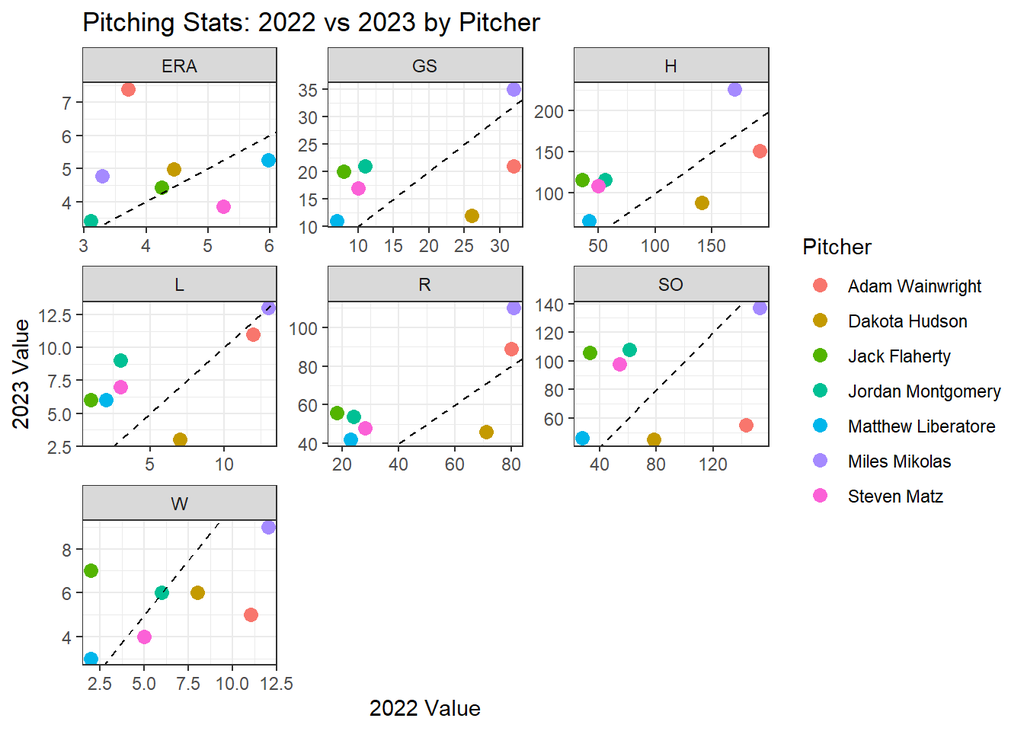

```r
# Reshape the data to long format
cards_plot_data <- cards_stats_named %>%
  pivot_longer(cols = c(ERA, R, W, H, L, GS, SO),
               names_to = "stat",
               values_to = "value") %>%
  pivot_wider(names_from = yearID, values_from = value, names_prefix = "year_") %>%
  filter(!is.na(year_2022) & !is.na(year_2023))  # Ensure both years are present

# Plot
ggplot(cards_plot_data, aes(x = year_2022, y = year_2023, color = player_name)) +
  geom_point(size = 3) +
  geom_abline(slope = 1, intercept = 0, linetype = "dashed") +
  facet_wrap(~stat, scales = "free") +
  labs(
    title = "Pitching Stats: 2022 vs 2023 by Pitcher",
    x = "2022 Value",
    y = "2023 Value",
    color = "Pitcher"
  ) +
  theme_bw()
```

As you can see from the plot above almost all categories are higher in 2023 for these starters. It is interesting to notice that Miles Mikolas stats are not that differing from past years, which showcases that he stayed about the same except in RA and ERA. There appears to be an increase all around of runs against, which is what we will research farther into factors that might have caused them to be hit off of.

It is also interesting that Adam Wainwright pitched in less games, but had more runs against. Looking into the differences in runs against by pitchers shows just how the ERA differs and why they were trended in a bad direction.

## Statcast Cardinals Starters

Now let’s use Statcast data on Cardinals Starters to find any differences. We will first look at each pitchers arsenal and see how that differed over the years.

```r
target_pitchers <- cards_stats_named$player_name

# Combine years
cards_pitch_all <- bind_rows(
  cards_pitch22 %>% mutate(year = 2022),
  cards_pitch23 %>% mutate(year = 2023)
)

# Filter to target pitchers only
pitchers_arsenal <- cards_pitch_all %>%
  filter(MLBNAME %in% target_pitchers) %>%
  filter(!is.na(pitch_name)) %>%
  group_by(MLBNAME, year, pitch_name) %>%
  summarise(n = n(), .groups = "drop") %>%
  arrange(MLBNAME, year, desc(n))

pitcher_usage <- pitchers_arsenal %>%
  group_by(MLBNAME, year) %>%
  mutate(usage = round(n / sum(n), 4)) %>%
  ungroup()
pitcher_usage
```

```
## # A tibble: 78 × 5
##    MLBNAME          year pitch_name          n  usage
##    <chr>           <dbl> <chr>           <int>  <dbl>
##  1 Adam Wainwright  2022 Curveball         960 0.306
##  2 Adam Wainwright  2022 Sinker            874 0.279
##  3 Adam Wainwright  2022 Cutter            784 0.250
##  4 Adam Wainwright  2022 4-Seam Fastball   290 0.0926
##  5 Adam Wainwright  2022 Changeup          189 0.0603
##  6 Adam Wainwright  2022 Slow Curve         33 0.0105
##  7 Adam Wainwright  2022 Slider              3 0.001
##  8 Adam Wainwright  2023 Sinker            560 0.314
##  9 Adam Wainwright  2023 Curveball         546 0.306
## 10 Adam Wainwright  2023 Cutter            404 0.226
## # ℹ 68 more rows
```

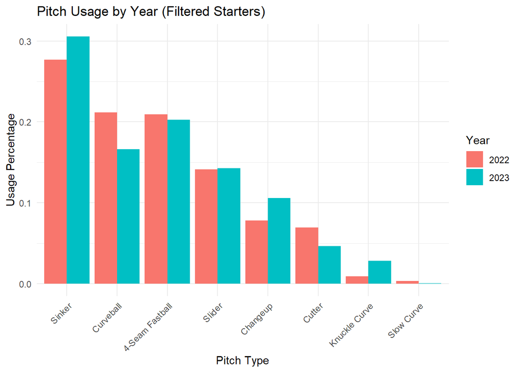

```r
total_usage <- pitcher_usage %>%
  group_by(year, pitch_name) %>%
  summarise(tot = sum(n), .groups = "drop")
total_usage <- total_usage %>%
  group_by(year) %>%
  mutate(usage = round(tot / sum(tot), 4)) %>%
  ungroup()
pitch_order <- total_usage %>%
  filter(year == 2022) %>%
  arrange(desc(usage)) %>%
  pull(pitch_name)

total_usage$pitch_name <- factor(total_usage$pitch_name, levels = pitch_order)

ggplot(total_usage, aes(x = pitch_name, y = usage, fill = factor(year))) +
  geom_bar(stat = "identity", position = "dodge") +
  labs(
    title = "Pitch Usage by Year (Filtered Starters)",
    x = "Pitch Type",
    y = "Usage Percentage",
    fill = "Year"
  ) +
  theme_minimal() +
  theme(axis.text.x = element_text(angle = 45, hjust = 1))
```

Here you can find that starters use Sinker considerably more and started to decrease in Curveball.

## Pitch Location

Since we know that they like to throw certain pitches more, lets look at locations of where these pitchers are going.

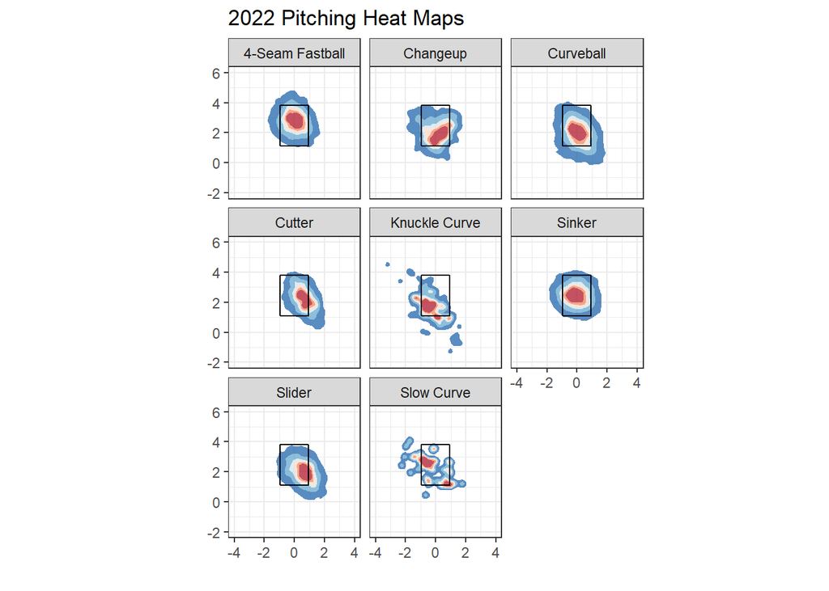

```r
Cards_starters_sc <- cards_pitch_all %>%
  filter(MLBNAME %in% target_pitchers) %>%
  filter(!is.na(pitch_name))

location_func(Cards_starters_sc %>% filter(year == 2022)) +
  labs(title = '2022 Pitching Heat Maps')
```

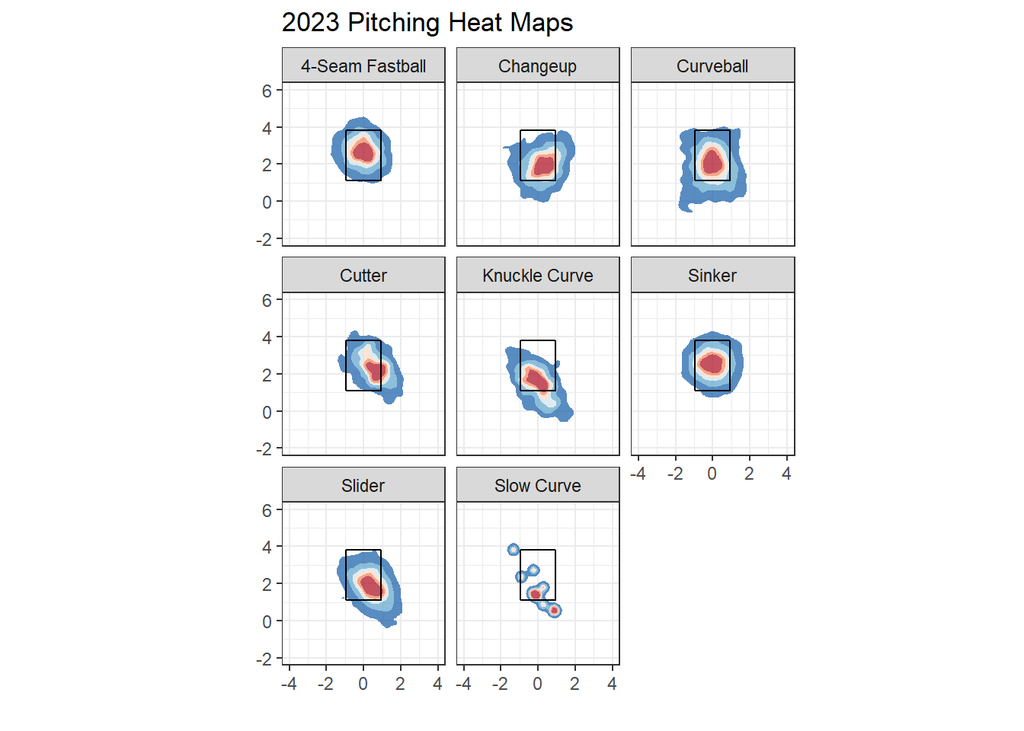

```r
location_func(Cards_starters_sc %>% filter(year == 2023)) +
  labs(title = '2023 Pitching Heat Maps')
```

As you can see true heat maps do not tell a full story of actually what is happening in the games. I want to seperate hits vs nonhits to see what the pitches looked like when they were being put into play.

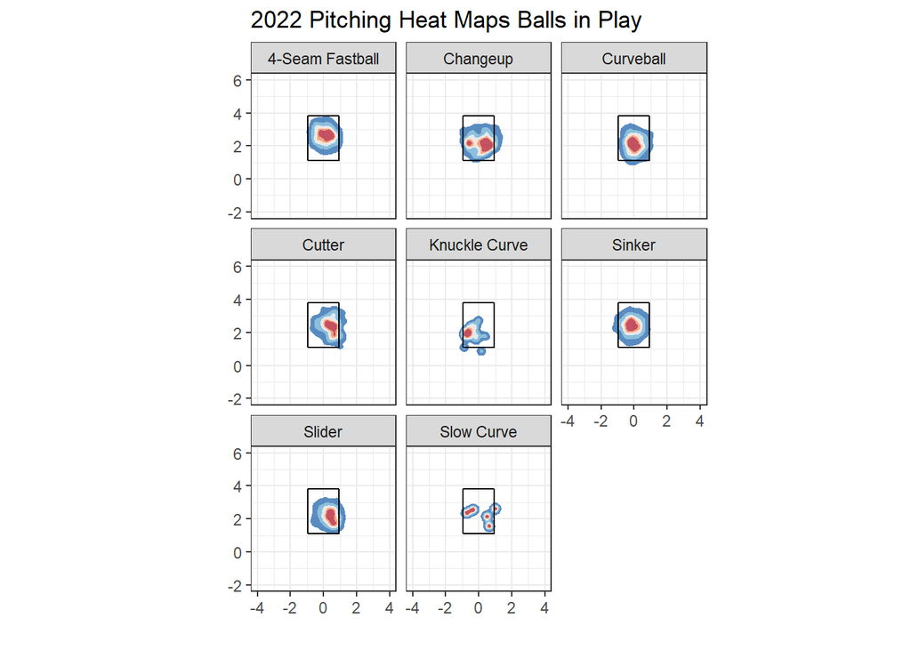

```r
play22 <- Cards_starters_sc %>% filter(year == 2022 & type == 'X')
location_func(play22) +
  labs(title = '2022 Pitching Heat Maps Balls in Play')
```

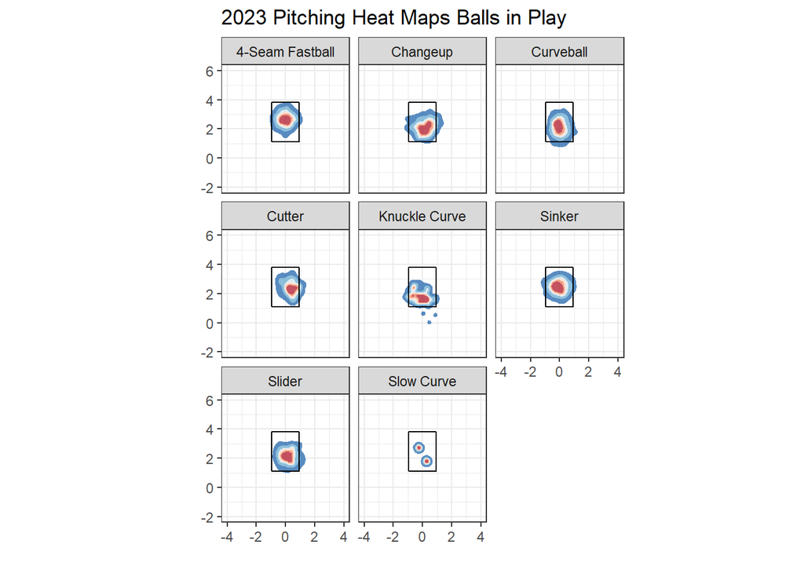

```r
play23 <- Cards_starters_sc %>% filter(year == 2023 & type == 'X')
location_func(play23) +
  labs(title = '2023 Pitching Heat Maps Balls in Play')
```

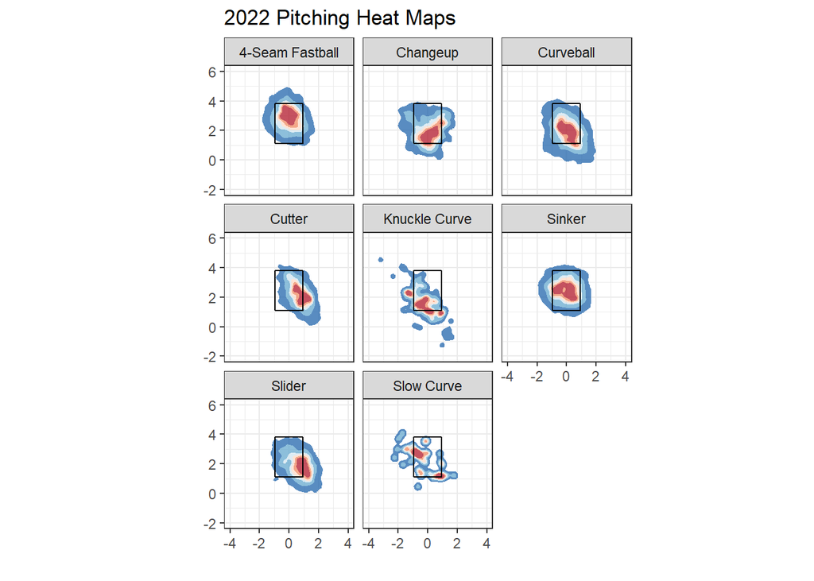

```r
miss22 <- Cards_starters_sc %>% filter(year == 2022 & type != 'X')
location_func(miss22) +
  labs(title = '2022 Pitching Heat Maps')
```

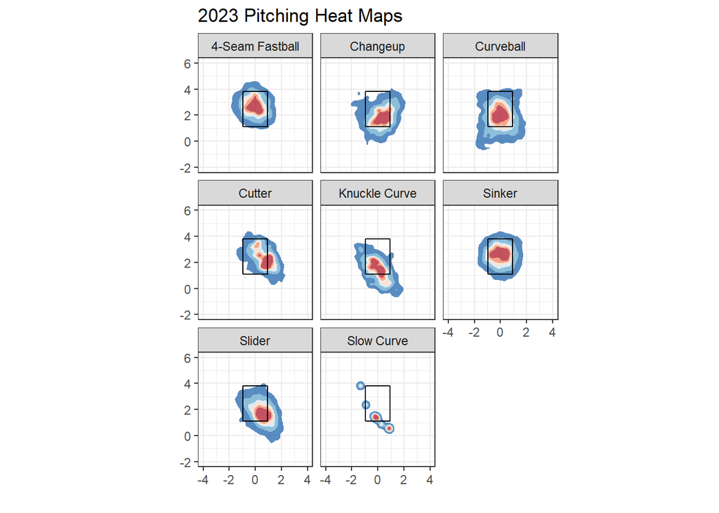

```r
miss23 <- Cards_starters_sc %>% filter(year == 2023 & type != 'X')
location_func(miss23) +
  labs(title = '2023 Pitching Heat Maps')
```

The heat maps are definitely a lot tighter for Balls in Play. The Cardinals do pitch for contact and you can see the differences in how they are just throwing strikes to make sure that they can try and get outs. We can see that the Cardinals do throw a lot of pitches over the plate and care more about throwing strikes than anything else. Since there does not seem to be a large change in location of the heatmaps, lets take a look at the effectiveness of each pitch type and what it was doing.

## Effects of Each Pitch

We will now look into the details of each pitch type and also what were there any differences in pitch statistics such as spin rate, movement, and other factors.

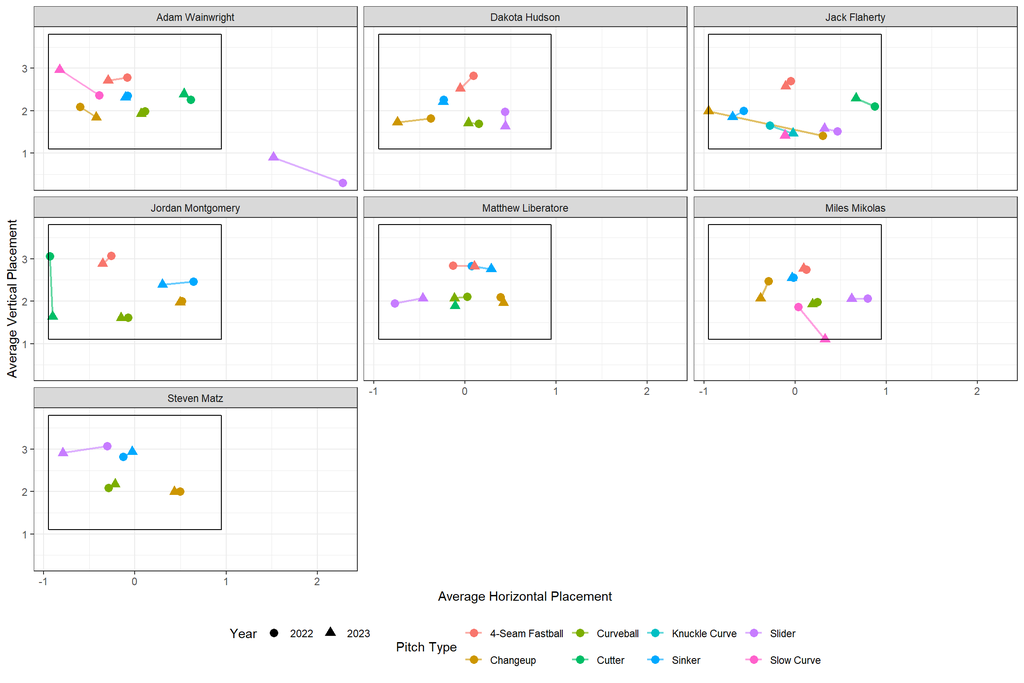

```r
# Find Averages of all pitch stats
cards_sc <- Cards_starters_sc %>%
  group_by(MLBNAME, year, pitch_name) %>%
  summarise(
    avg_spin = mean(release_spin_rate, na.rm = TRUE),
    avg_velo = mean(release_speed, na.rm = TRUE),
    avg_x = mean(plate_x, na.rm = TRUE),
    avg_z = mean(plate_z, na.rm = TRUE),
    avg_horizontal = mean(pfx_x, na.rm = TRUE),
    avg_vertical = mean(pfx_z, na.rm = TRUE),
    avg_striket = mean(strike_zone_top),
    avg_strikeb = mean(strike_zone_bottom),
    .groups = "drop"
  )

ggplot(cards_sc, aes(x = avg_x, y = avg_z, color = pitch_name))+
  geom_line(aes(group = interaction(MLBNAME, pitch_name)), linewidth = 0.8, alpha = 0.6) +
  geom_point(aes(shape = factor(year)), size = 3) +
  geom_strikezone() +
  facet_wrap(~MLBNAME) +
  theme_bw() +
  theme(legend.position = 'bottom') +
    labs(
    x = "Average Horizontal Placement",
    y = "Average Vertical Placement",
    color = "Pitch Type",
    shape = "Year"
  )
```

The plot above shows the differences in average pitch location between years. As you can see most of the pitchers average location for each pitch moved towards the middle or towards the inside of right handed hitter. These locations are the from the catchers perspective and thus can show the difference in where a catcher calls a pitch. For example most pitches were on the left side and you can see where the majority of the pitches were moving towards the middle. Looking at Flaherty you can see major changes in changeup location and Matz has huge differences in slider location. These changes in location most likely have to do with changes in strategy of game calling by these pitchers and how they want to attack hitters.

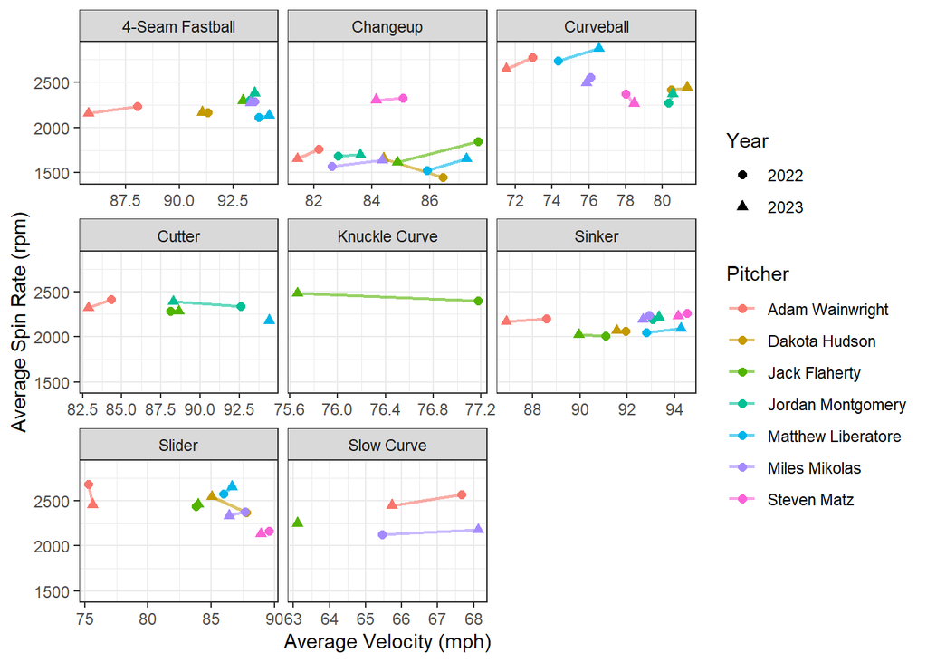

```r
ggplot(cards_sc, aes(x = avg_velo, y = avg_spin, color = MLBNAME)) +
  geom_line(aes(group = interaction(MLBNAME, pitch_name)), linewidth = 0.8, alpha = 0.6) +
  geom_point(aes(shape = factor(year)), size = 2) +
  facet_wrap(~pitch_name, scales = 'free_x') +
  theme_bw() +
  labs(
    x = "Average Velocity (mph)",
    y = "Average Spin Rate (rpm)",
    color = "Pitcher",
    shape = "Year"
  )
```

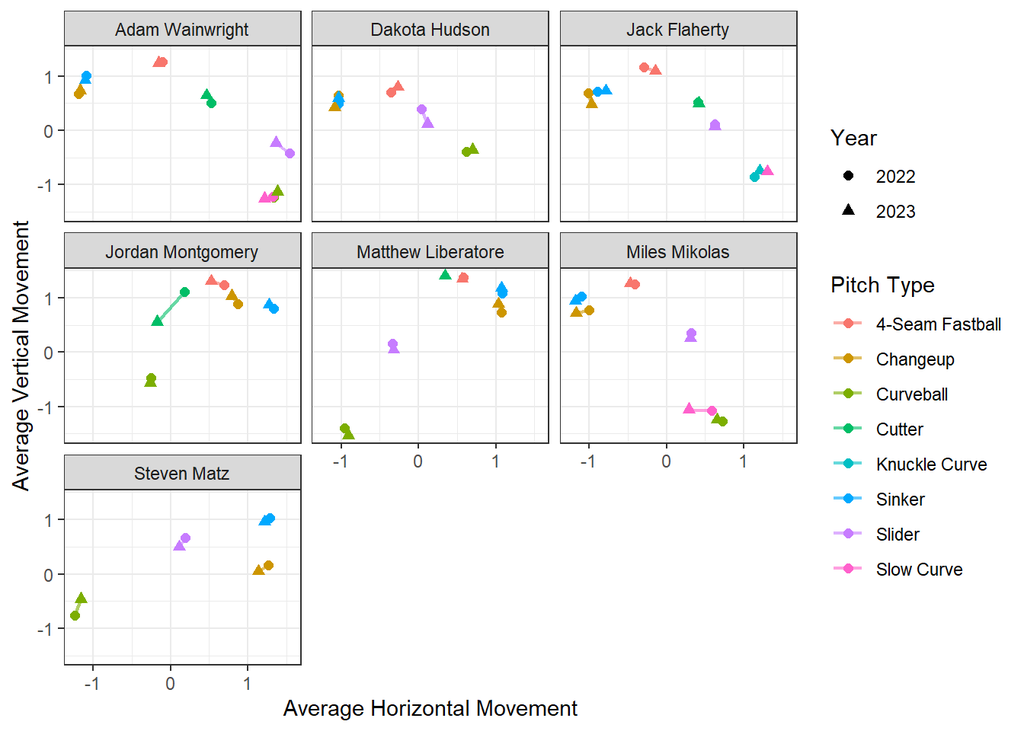

```r
ggplot(cards_sc, aes(x = avg_horizontal, y = avg_vertical, color = pitch_name)) +
  geom_line(aes(group = interaction(MLBNAME, pitch_name)), linewidth = 0.8, alpha = 0.6) +
  geom_point(aes(shape = factor(year)), size = 2) +
  facet_wrap(~MLBNAME) +
  theme_bw() +
  labs(
    x = "Average Horizontal Movement",
    y = "Average Vertical Movement",
    color = "Pitch Type",
    shape = "Year"
  )
```

This plot shows the horizontal movement and vertical movement differences for each pitcher and pitch type. There is not really any significant differences when looking at averages of the movements of pitches. This would lead me to believe that the pitchers were not having less movement, but rather slower spin and velocity. The ball was still moving, not a lot compared to other pitchers who throw more off speed pitches, but still moving like they normally do.

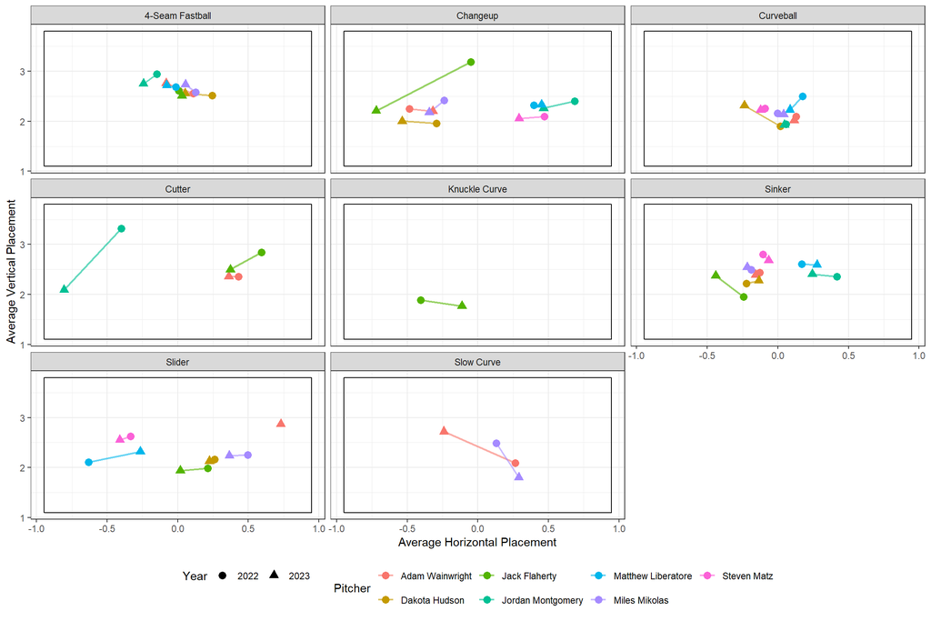

```r
# Find Averages of all pitch stats in play
cards_play <- Cards_starters_sc %>%
  filter(type == 'X') %>%
  group_by(MLBNAME, year, pitch_name) %>%
  summarise(
    avg_spin = mean(release_spin_rate, na.rm = TRUE),
    avg_velo = mean(release_speed, na.rm = TRUE),
    avg_x = mean(plate_x, na.rm = TRUE),
    avg_z = mean(plate_z, na.rm = TRUE),
    avg_horizontal = mean(pfx_x, na.rm = TRUE),
    avg_vertical = mean(pfx_z, na.rm = TRUE),
    avg_striket = mean(strike_zone_top),
    avg_strikeb = mean(strike_zone_bottom),
    .groups = "drop"
  )

ggplot(cards_play, aes(x = avg_x, y = avg_z, color = MLBNAME))+
  geom_line(aes(group = interaction(MLBNAME, pitch_name)), linewidth = 0.8, alpha = 0.6) +
  geom_point(aes(shape = factor(year)), size = 3) +
  geom_strikezone() +
  facet_wrap(~pitch_name) +
  theme_bw() +
  theme(legend.position = 'bottom') +
  labs(
    x = "Average Horizontal Placement",
    y = "Average Vertical Placement",
    color = "Pitcher",
    shape = "Year"
  )
```

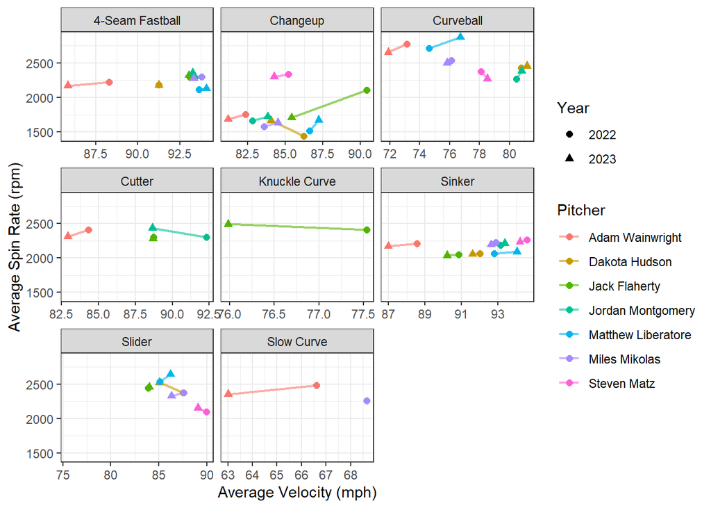

```r
ggplot(cards_play, aes(x = avg_velo, y = avg_spin, color = MLBNAME)) +
  geom_line(aes(group = interaction(MLBNAME, pitch_name)), linewidth = 0.8, alpha = 0.6) +
  geom_point(aes(shape = factor(year)), size = 2) +
  facet_wrap(~pitch_name, scales = 'free_x') +
  theme_bw() +
  labs(
    x = "Average Velocity (mph)",
    y = "Average Spin Rate (rpm)",
    color = "Pitcher",
    shape = "Year"
  )
```

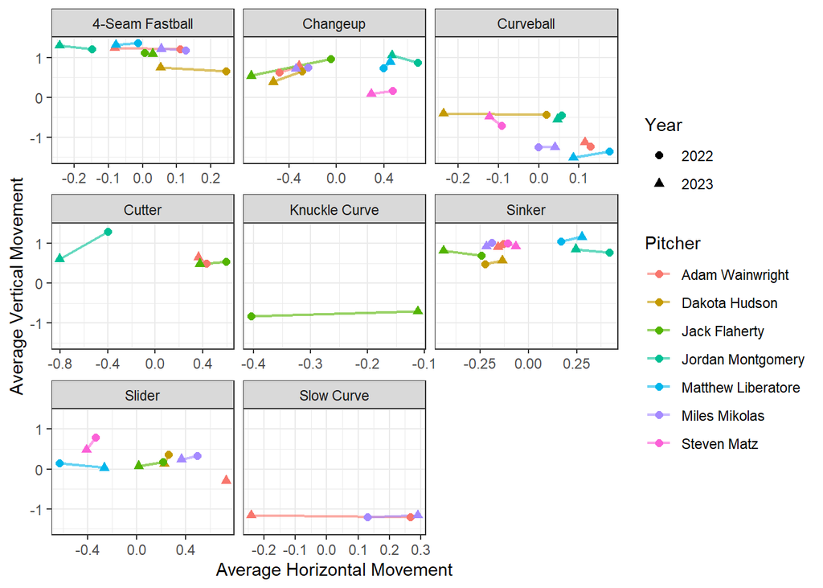

```r
ggplot(cards_play, aes(x = avg_x, y = avg_vertical, color = MLBNAME)) +
  geom_line(aes(group = interaction(MLBNAME, pitch_name)), linewidth = 0.8, alpha = 0.6) +
  geom_point(aes(shape = factor(year)), size = 2) +
  facet_wrap(~pitch_name, scales = 'free_x') +
  theme_bw() +
  labs(
    x = "Average Horizontal Movement",
    y = "Average Vertical Movement",
    color = "Pitcher",
    shape = "Year"
  )
```

# Conclusion

Looking at all of the data that came from the Cardinals 2023 season, it appears that the Cardinals got ‘caught’ and ‘exposed’ during the 2023 season. There were some rule changes that drastically hurt the Cardinals idea of pitching contact style rather than strikeouts. The ban of the shift was a big one that I will show below.

```r
Cards_starters_sc %>%
  group_by(year, if_fielding_alignment) %>%
  summarise(tot = n(), .groups = 'drop')
```

```
## # A tibble: 8 × 3
##    year if_fielding_alignment   tot
##   <dbl> <chr>                 <int>
## 1  2022 Infield shade           295
## 2  2022 Infield shift          3773
## 3  2022 Standard               6385
## 4  2022 Strategic              1248
## 5  2023 Infield shade          3076
## 6  2023 Standard               8680
## 7  2023 Strategic              1169
## 8  2023 <NA>                    184
```

As you can see the Cardinals had to go from using the shift on 3773 pitches for their starters to not being able to use it a single time. They had to relay on an infield shade, which is just moving the second basemen or shortstop closer to second base, but that is not the same as shifting the infield to having more than 2 infielders on a side of second base. The Cardinals outdated ideas of pitch for contact were exposed during this season when there was not a way to defend the same way. The Cardinals gave up more hits than they had in recent history and that is probably partially due to these factors.

There is still a lot of data to explore and other aspects of this team to look at, but looking at the starting pitchers data, it was easily seen that they were performing worse and some causes that could have led to it. I do not believe it was Willson Contreras’s fault that the pitching was so bad at the start of the season, he was a scapegoat for the pitchers and there is data to show that they were not as good.